# Statistical Inference Course : Project 2

Han Yunxi

18 January 2015

### Analysis of ToothGrowth data in R dataset

This project requires us to load the **ToothGrowth** data from the default dataset in R and perform to some basic exploratory data analyses and provide a basic summary of the data.

### Basic Data Exploration & Summary

For basic data exploration, We first load the **R** library **ToothGrowth** dataset and use the command `library(help = "datasets")` to understand the dataset. From the description, we understand the dataset title is: **The Effect of Vitamin C on Tooth Growth in Guinea Pigs**.

```r
  library(datasets)
  str(ToothGrowth)      #structure of the dataset
```

```
## 'data.frame':    60 obs. of  3 variables:
##  $ len : num  4.2 11.5 7.3 5.8 6.4 10 11.2 11.2 5.2 7 ...
##  $ supp: Factor w/ 2 levels "OJ","VC": 2 2 2 2 2 2 2 2 2 2 ...
##  $ dose: num  0.5 0.5 0.5 0.5 0.5 0.5 0.5 0.5 0.5 0.5 ...
```

```r
  summary(ToothGrowth)  #table summary
```

```
##       len        supp         dose
##  Min.   : 4.20   OJ:30   Min.   :0.500
##  1st Qu.:13.07   VC:30   1st Qu.:0.500
##  Median :19.25           Median :1.000
##  Mean   :18.81           Mean   :1.167
##  3rd Qu.:25.27           3rd Qu.:2.000
##  Max.   :33.90           Max.   :2.000
```

The dataset is a [60 rows by 3 columns] dataframe and contains information on (a) Length of tooth - `len`, (b) Supplement Type - `supp` and (c) Dosage given - `dose`.

In addition, we find that the maximum tooth length is *33.9* and the minimum is *4.2*, with the average tooth growth length at *18.81*. There are only 2 types of supplement (Orange Juice or Vitamin C). For the dosage level, we find that there are only 3 levels of dosage (0.5,1 and 2).

We also plot the dataset below to understand the effects of supplement and dosage on tooth growth. From the plot, we can see that Vitamin C results in larger range of tooth growth **(i.e. larger variance)** and Orange Juice gives limited but more predictable growth **(i.e. more points centred around a particular region)**

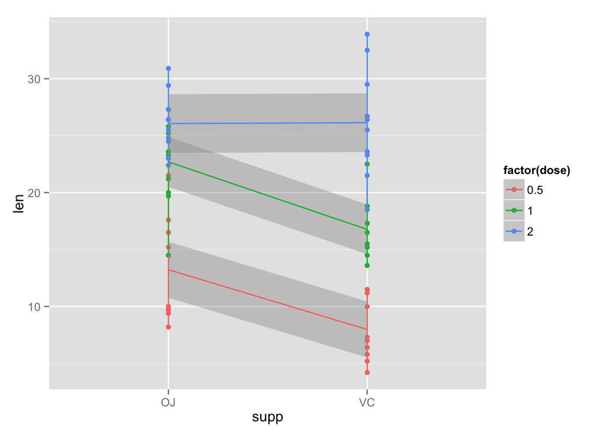

```r
  library(ggplot2)
  qplot(supp, len, data=ToothGrowth, colour=factor(dose)) +
  geom_line(data=ToothGrowth) +
  geom_smooth(aes(group=dose), method="lm")
```

### Statistical Inference

For the next section, we use confidence intervals and/or hypothesis tests to compare tooth growth by supplement and dose.

#### Assumptions

We assume that $iid$ samples are used and that the results give a precise estimates of effects.

For small samples of only 10, we assume that Gosset’s $t$ distribution. We also assume the distribution of the data is roughly symmetric and mound shaped.

Paired observations are often analyzed using the $t$ interval by taking differences. We assume that the ToothGrowth dataset is paired, i.e. OJ and VC is given to same 10 test subjects.

R function `myCI` takes in the *dosage* parameter and calculates the 95% confidence interval of the tooth growth length. The function is as seen below.

```r
  library(dplyr)
  myCI <- function(dosage){
    vitaminGroup <- filter(ToothGrowth, supp == "VC", dose == dosage)
    orangeGroup <- filter(ToothGrowth, supp == "OJ", dose == dosage)

    difference <- orangeGroup$len - vitaminGroup$len
    mn <- mean(difference)
    s <- sd(difference)
    n <- 10

    CI <- round(mn + c(-1, 1) * qt(.975, n-1) * s / sqrt(n) , 2)
    t.test(difference)$conf.int
    cat("For dosages of", dosage ,"mg, Orange Juice supplements affects tooth growth than Vitamin C by (", CI , ")mm at 95% confidence interval.")
  }
```

#### Results - Confidence Intervals for 0.5, 1.0 and 2.0 mg dosage

```r
  myCI(0.5)
```

```
## For dosages of 0.5 mg, Orange Juice supplements affects tooth growth than Vitamin C by ( 1.26 9.24 )mm at 95% confidence interval.
```

```r
  myCI(1.0)
```

```
## For dosages of 1 mg, Orange Juice supplements affects tooth growth than Vitamin C by ( 1.95 9.91 )mm at 95% confidence interval.
```

```r
  myCI(2.0)
```

```
## For dosages of 2 mg, Orange Juice supplements affects tooth growth than Vitamin C by ( -4.33 4.17 )mm at 95% confidence interval.
```

```r
require(graphics)

predict(lm(ToothGrowth), se.fit = TRUE, scale = NULL,
        interval = c("confidence"),
        level = 0.95, type = c("response", "terms"),
        terms = NULL, na.action = na.pass,
        pred.var = res.var/weights, weights = 1)
```

```
## $fit
##         fit       lwr      upr
## 1  10.45429  8.513142 12.39543
## 2  10.45429  8.513142 12.39543
## 3  10.45429  8.513142 12.39543
## 4  10.45429  8.513142 12.39543
## 5  10.45429  8.513142 12.39543
## 6  10.45429  8.513142 12.39543
## 7  10.45429  8.513142 12.39543
## 8  10.45429  8.513142 12.39543
## 9  10.45429  8.513142 12.39543
## 10 10.45429  8.513142 12.39543
## 11 15.33607 13.760165 16.91198
## 12 15.33607 13.760165 16.91198
## 13 15.33607 13.760165 16.91198
```

[output cut: 64 more lines]

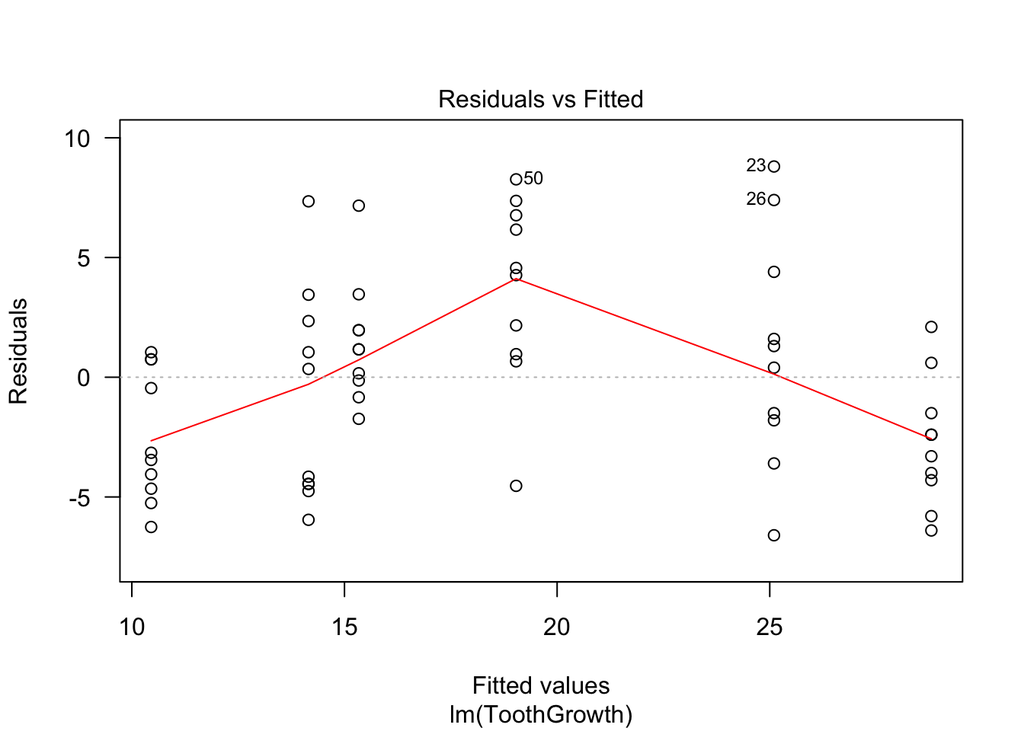

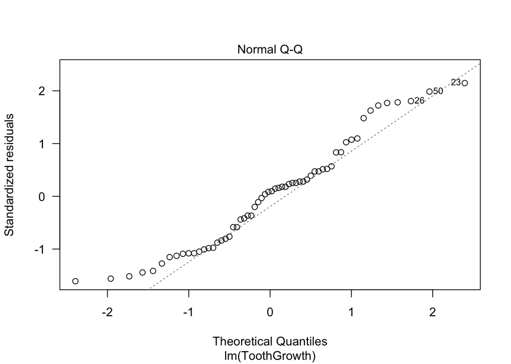

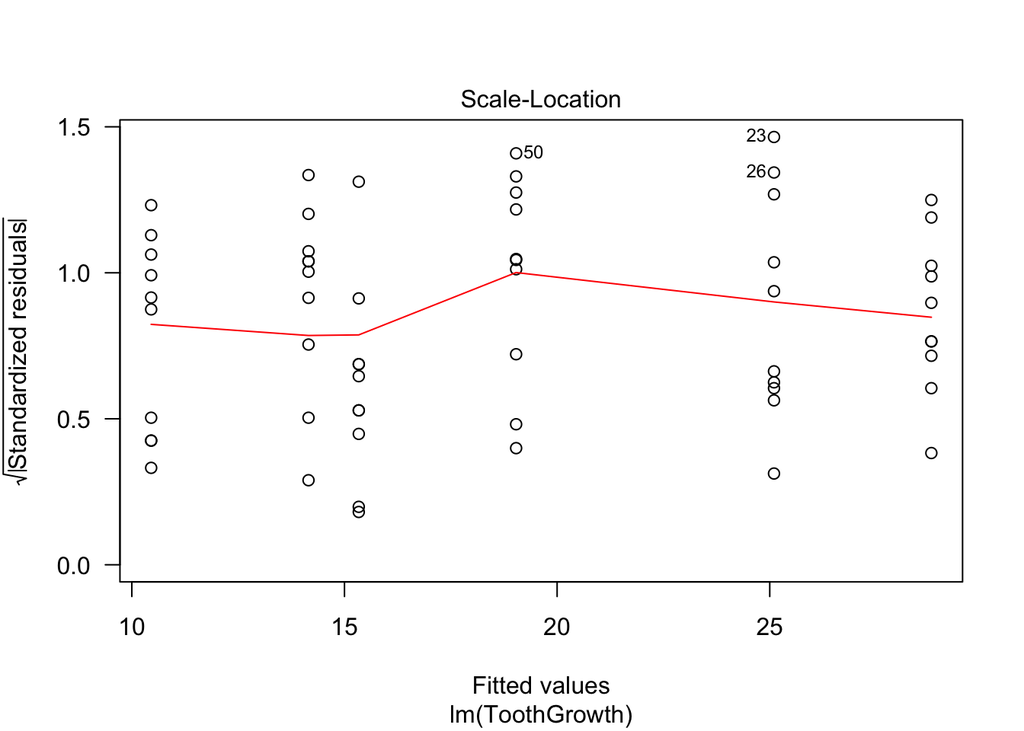

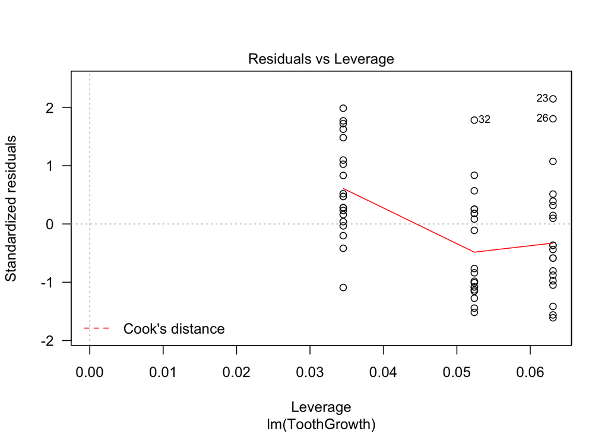

```r
plot(lm(ToothGrowth),las=1)
```